# Python 101 for Non-Programmers

# and Hopefully the Public Good

### Brian J. McGuirk

### Agency IT Manager, Department of Business Regulation

# How many people here identify as programmers or developers?

# I got news for you.

# You're all programmers.

# If you can understand this from last month...

[figure not shown]

# Or rock a Pivot Table...

[figure not shown]

# You're a programmer.

# You have the skills. You need more power.

[figure not shown]

# Like Python.

# Python?

## It’s a Programming Language and Ecosystem.

## It's Named after Monty Python’s Flying Circus.

[figure not shown]

## It's been around since 1991.

## And was invented by a genius Dutchman named Guido (GEE-do) van Rossum.

[figure not shown]

*Legend*

*I met him once.*

## And it's now one of the most popular languages in the world.

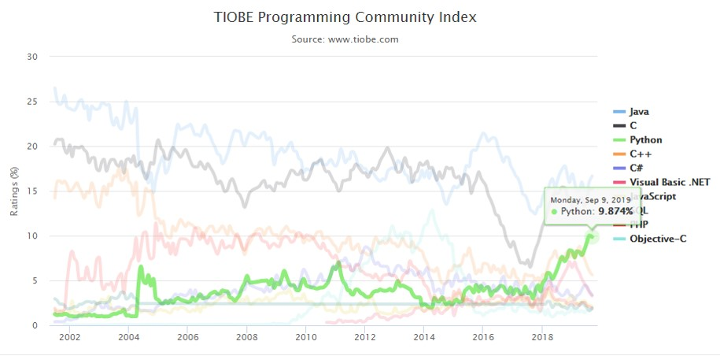

# Why?

- Easy to Learn
- Easy to Understand
- Flexible
- Massive Open Source Community
- Industry-Supported

# Python Offers World-Class...

- Data Science
- Machine Learning
- Automation
- Web Tools

# And it won a Nobel Prize.

[figure not shown]

*Economist Paul Romer, Co-Winner of the 2018 Nobel Prize*

# "That sounds hard."

[figure not shown]

# It's not. I'll show you.

[figure not shown]

# Here we go:

- "Hello World."
- Variables and Types
- Lists
- Basic Operators/Operations
- Fun with Strings
- Conditions and Loops
- Dictionaries
- Packages
- **DATA SCIENCE**
- An Example Walkthrough

```python
# This is a comment. It will not be executed.
print("Hello World.")
```

```
Hello World.
```

# There. We just programmed something!

## What if you wanted to store that text and do something with it later?

### Easy.

```python
greeting = "Hello World."
```

```python
print(greeting)
```

```
Hello World.
```

## This is called "assignment" of a Variable.

```python
age = 36
```

### Why's 36 a different color?

```python
print(age)
```

```
36
```

### Still looks the same...

```python
type(age)
```

```
int
```

# Python figured it out for you.

# You're welcome.

# But types can be tricky.

```python
age + greeting
```

```
---------------------------------------------------------------------------
TypeError                                 Traceback (most recent call last)
<ipython-input-8-f39bf97b9eb0> in <module>
----> 1 age + greeting

TypeError: unsupported operand type(s) for +: 'int' and 'str'
```

```python
str(age) + greeting
```

```
'36Hello World.'
```

# Or...

```python
greeting + " I'm " + str(age) + "."
```

```
"Hello World. I'm 36."
```

# Assignment can be flexible, too:

```python
x, y = 14, 38
```

```python
print(x)
print(y)
```

```
14
38
```

# Lists

Really good at storing something. Anything. And making it accessible.

And they're easy to create:

```python
mylist = [greeting, age, x, y]
```

### That's it. Brackets.

### And then it's accessible.

```python
print(mylist)
```

```
['Hello World.', 36, 14, 38]
```

```python
# Appending is easy.
mylist.append('An appendix')
print(mylist)
```

```
['Hello World.', 36, 14, 38, 'An appendix']
```

```python
# Can we combine them?
secondlist = ['this', 'is', 'just', 'a', 'test', 2]
secondlist + mylist
```

```
['this',
 'is',
 'just',
 'a',
 'test',
 2,
 'Hello World.',
 36,
 14,
 38,
 'An appendix']
```

# Operators

- Already touched on them, but these do what you would think:
  - `+`
  - `-`
  - `*`
  - `/`
- And there's also modulo `%`, which gives you the remainder of a division.
- And `**` which raises to a power.

```python
print(3 + 15)
print(3 - 15)
print(3 * 15)
print(15 / 3)
print(15 % 3)
print(15 ** 3)
```

```
18
-12
45
5.0
0
3375
```

### Works with Lists, too.

### But maybe not in the way you thought...

```python
intlist = [2,4,9,11,24]
intlist * 2
```

```
[2, 4, 9, 11, 24, 2, 4, 9, 11, 24]
```

# Loops

### For when you have to do one thing to lots of things.

```python
# For Loop
intlist = [2,4,9,11,24]
for number in intlist:
    print(number * 2)
```

```
4
8
18
22
48
```

```python
# While Loop

i = 0
while i < 10:
    print(i)
    i = i + 1
```

```
0
1
2
3
4
5
6
7
8
9
```

# What is truth?

Python recognizes the words `True` and `False`.

## `=` is for Assigning Variables

## `==` is for Truthiness

[figure not shown]

## `!=` is for Falseness

```python
# We've always been at war with East Anglia.
1 + 1 == 2
```

```
True
```

```python
"Stephen" == "Colbert"
```

```
False
```

```python
stephen = False
colbert = False
print(stephen == colbert)
```

```
True
```

```python
# If / Else Pattern
i = 1
while i < 10:
    if 10 % i == 0:
        print(i)
    else:
        print("Nope")
    i = i + 1
```

```
1
2
Nope
Nope
5
Nope
Nope
Nope
Nope
```

# Dictionaries

[figure not shown]

### I may skip this in real-time.

```python
# Note the curly brackets.

house_points = {'Hufflepuff': 411,
              'Gryffindor': 371,
              'Ravenclaw': 355,
              'Slytherin': 194}
```

```python
# How many points for Hufflepuff?
house_points['Hufflepuff']
```

```
411
```

```python
house_points.get('Gryffindor')
```

```
371
```

```python
house_points.keys()
```

```
dict_keys(['Hufflepuff', 'Gryffindor', 'Ravenclaw', 'Slytherin'])
```

```python
house_points.values()
```

```
dict_values([411, 371, 355, 194])
```

# If you know the key, you can get the value.

# There are other cool collections, but you'll have to discover those on your own.

[figure not shown]

# Packages!

# Data!

## Let the world do your work for you!

# Python is a MASSIVE Open-Source Community

## PyPi.org is the central package repository for Python.

*[Link](https://pypi.org/)*

### Hosts 196,922 projects

# Python is the 3rd Most Popular Language on GitHub

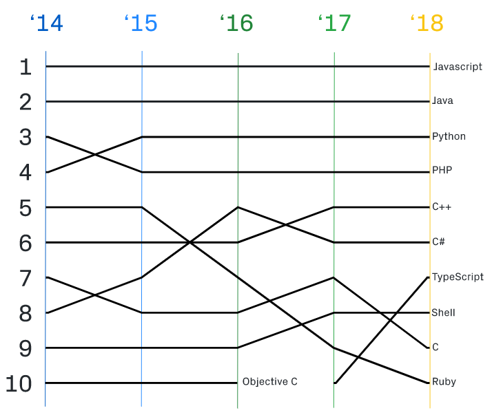

*[Source](https://octoverse.github.com/projects#languages)*

```python
import pandas as pd
import numpy as np
```

# Let's look at some soccer results. Sadly, men's teams only.

[figure not shown]

```python
# Tell Pandas to create a DataFrame from a CSV file.
df = pd.read_csv('results.csv')
```

```python
# What's going on in this data?
df.info()
```

[output not shown]

# Let's get preview of the top 5 rows.

```python
df.head()
```

|  | date | home_team | away_team | home_score | away_score | tournament | city | country | neutral |
| --- | --- | --- | --- | --- | --- | --- | --- | --- | --- |
| 0 | 1872-11-30 | Scotland | England | 0 | 0 | Friendly | Glasgow | Scotland | False |
| 1 | 1873-03-08 | England | Scotland | 4 | 2 | Friendly | London | England | False |
| 2 | 1874-03-07 | Scotland | England | 2 | 1 | Friendly | Glasgow | Scotland | False |
| 3 | 1875-03-06 | England | Scotland | 2 | 2 | Friendly | London | England | False |
| 4 | 1876-03-04 | Scotland | England | 3 | 0 | Friendly | Glasgow | Scotland | False |

### We can access individual columns, called Series, the same way we accessed the dictionary.

```python
df['date'].head()
```

[output not shown]

# How often do we want counts by unique values?

```python
df['home_team'].value_counts()
```

```
Brazil                       563
Argentina                    545
Mexico                       510
Germany                      501
England                      489
Sweden                       483
France                       480
South Korea                  463
Hungary                      450
Italy                        441
Austria                      416
United States                416
Netherlands                  414
Belgium                      409
Denmark                      401
Switzerland                  401
Norway                       395
Chile                        390
Poland                       381
Egypt                        377
Scotland                     374
Japan                        368
Kenya                        363
Saudi Arabia                 358
Spain                        356
Uruguay                      342
China PR                     334
Malawi                       331
Thailand                     328
Finland                      326
                            ...
Canary Islands                 4
Darfur                         4
Gozo                           3
Wallis Islands and Futuna      3
Găgăuzia                       3
Timor-Leste                    3
Western Sahara                 3
Arameans Suryoye               3
Manchukuo                      2
Niue                           2
Parishes of Jersey             2
Matabeleland                   2
Vatican City                   2
Micronesia                     2
Cascadia                       2
Felvidék                       2
Yemen DPR                      2
Raetia                         2
Palau                          2
Somaliland                     2
Romani people                  1
Curacao                        1
Central Spain                  1
Sark                           1
Saint Helena                   1
St. Pierre & Miquelon          1
Kabylia                        1
Madrid                         1
Crimea                         1
Chameria                       1
Name: home_team, Length: 309, dtype: int64
```

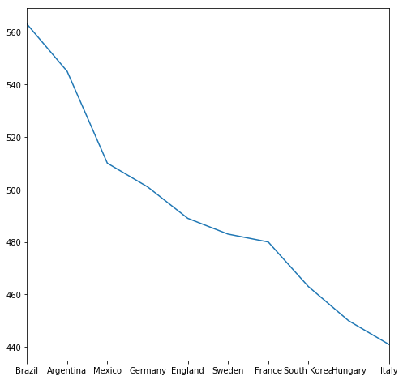

```python
# Same thing, but take the top ten, and do a simple plot.
df['home_team'].value_counts().head(10).plot(figsize=(8,8))
```

```python
# What was the highest home score?
df['home_score'].max()
```

```
31
```

```python
# Highest away score?
df['away_score'].max()
```

```
21
```

# Let's create some new data.

```python
df.head()
```

|  | date | home_team | away_team | home_score | away_score | tournament | city | country | neutral |
| --- | --- | --- | --- | --- | --- | --- | --- | --- | --- |
| 0 | 1872-11-30 | Scotland | England | 0 | 0 | Friendly | Glasgow | Scotland | False |
| 1 | 1873-03-08 | England | Scotland | 4 | 2 | Friendly | London | England | False |
| 2 | 1874-03-07 | Scotland | England | 2 | 1 | Friendly | Glasgow | Scotland | False |
| 3 | 1875-03-06 | England | Scotland | 2 | 2 | Friendly | London | England | False |
| 4 | 1876-03-04 | Scotland | England | 3 | 0 | Friendly | Glasgow | Scotland | False |

```python
df['total_goals'] = df['home_score'] + df['away_score']
```

```python
df.head()
```

|  | date | home_team | away_team | home_score | away_score | tournament | city | country | neutral | total_goals |
| --- | --- | --- | --- | --- | --- | --- | --- | --- | --- | --- |
| 0 | 1872-11-30 | Scotland | England | 0 | 0 | Friendly | Glasgow | Scotland | False | 0 |
| 1 | 1873-03-08 | England | Scotland | 4 | 2 | Friendly | London | England | False | 6 |
| 2 | 1874-03-07 | Scotland | England | 2 | 1 | Friendly | Glasgow | Scotland | False | 3 |
| 3 | 1875-03-06 | England | Scotland | 2 | 2 | Friendly | London | England | False | 4 |
| 4 | 1876-03-04 | Scotland | England | 3 | 0 | Friendly | Glasgow | Scotland | False | 3 |

```python
# Now what was the most goals ever scored in a game?
df['total_goals'].max()
```

```
31
```

### I want to know who played in that game!

```python
# In effect, create a Series of Truthiness.
df['total_goals'] > 30
```

```
0        False
1        False
2        False
3        False
4        False
5        False
6        False
7        False
8        False
9        False
10       False
11       False
12       False
13       False
14       False
```

[output cut: 47 more lines]

```python
# Then use that to filter/cut the dataframe.
df[df['total_goals'] > 30]
```

|  | date | home_team | away_team | home_score | away_score | tournament | city | country | neutral | total_goals |
| --- | --- | --- | --- | --- | --- | --- | --- | --- | --- | --- |
| 23781 | 2001-04-11 | Australia | American Samoa | 31 | 0 | FIFA World Cup qualification | Coffs Harbour | Australia | False | 31 |

```python
# How about the away goal craziness?
df[df['away_score'] > 20]
```

[output not shown]

```python
# Well, what was the distribution?
df.describe()
```

|  | home_score | away_score | total_goals |
| --- | --- | --- | --- |
| count | 40839.000000 | 40839.000000 | 40839.000000 |
| mean | 1.745709 | 1.188105 | 2.933813 |
| std | 1.749145 | 1.405120 | 2.092387 |
| min | 0.000000 | 0.000000 | 0.000000 |
| 25% | 1.000000 | 0.000000 | 1.000000 |
| 50% | 1.000000 | 1.000000 | 3.000000 |
| 75% | 2.000000 | 2.000000 | 4.000000 |
| max | 31.000000 | 21.000000 | 31.000000 |

```python
df.groupby(['home_team']).sum().sort_values(by='total_goals', ascending=False)
```

| home_team | home_score | away_score | neutral | total_goals |
| --- | --- | --- | --- | --- |
| Brazil | 1396 | 466 | 228.0 | 1862 |
| Germany | 1231 | 512 | 91.0 | 1743 |
| Sweden | 1129 | 554 | 37.0 | 1683 |
| Argentina | 1200 | 476 | 212.0 | 1676 |
| Hungary | 1057 | 542 | 32.0 | 1599 |
| England | 1123 | 438 | 52.0 | 1561 |
| Mexico | 1018 | 460 | 246.0 | 1478 |
| France | 956 | 521 | 52.0 | 1477 |
| Netherlands | 974 | 427 | 48.0 | 1401 |
| Belgium | 815 | 551 | 41.0 | 1366 |
| Austria | 814 | 548 | 27.0 | 1362 |
| Denmark | 853 | 499 | 34.0 | 1352 |
| South Korea | 921 | 342 | 165.0 | 1263 |
| Switzerland | 681 | 575 | 19.0 | 1256 |
| Italy | 875 | 349 | 77.0 | 1224 |
| Norway | 643 | 553 | 12.0 | 1196 |
| Chile | 720 | 469 | 105.0 | 1189 |
| Poland | 745 | 422 | 31.0 | 1167 |
| United States | 690 | 436 | 25.0 | 1126 |
| Finland | 474 | 633 | 23.0 | 1107 |
| Spain | 828 | 267 | 53.0 | 1095 |
| Scotland | 718 | 371 | 15.0 | 1089 |
| Japan | 679 | 408 | 114.0 | 1087 |
| Indonesia | 653 | 431 | 143.0 | 1084 |
| Egypt | 761 | 321 | 128.0 | 1082 |
| China PR | 715 | 322 | 110.0 | 1037 |
| Kenya | 609 | 406 | 125.0 | 1015 |
| Malaysia | 588 | 423 | 97.0 | 1011 |
| Australia | 675 | 317 | 76.0 | 992 |
| Romania | 644 | 335 | 42.0 | 979 |
| ... | ... | ... | ... | ... |
| United Koreans in Japan | 9 | 7 | 8.0 | 16 |
| Timor-Leste | 5 | 11 | 3.0 | 16 |
| Tibet | 2 | 13 | 4.0 | 15 |
| Republic of St. Pauli | 10 | 5 | 0.0 | 15 |
| Wallis Islands and Futuna | 8 | 6 | 3.0 | 14 |
| Parishes of Jersey | 11 | 3 | 0.0 | 14 |
| Canary Islands | 11 | 3 | 0.0 | 14 |
| Corsica | 8 | 5 | 0.0 | 13 |
| Cascadia | 10 | 3 | 1.0 | 13 |
| County of Nice | 7 | 5 | 4.0 | 12 |
| Somaliland | 7 | 5 | 2.0 | 12 |
| Găgăuzia | 2 | 9 | 3.0 | 11 |
| Gozo | 3 | 8 | 0.0 | 11 |
| Arameans Suryoye | 6 | 4 | 3.0 | 10 |
| Myanmar | 4 | 6 | 0.0 | 10 |
| Monaco | 8 | 2 | 4.0 | 10 |
| Manchukuo | 0 | 9 | 0.0 | 9 |
| Raetia | 1 | 6 | 2.0 | 7 |
| Saint Helena | 1 | 6 | 1.0 | 7 |
| Yemen DPR | 3 | 4 | 0.0 | 7 |
| Felvidék | 2 | 4 | 2.0 | 6 |
| Crimea | 0 | 5 | 1.0 | 5 |
| Chameria | 4 | 0 | 1.0 | 4 |
| Romani people | 1 | 3 | 1.0 | 4 |
| Madrid | 1 | 2 | 0.0 | 3 |
| Kabylia | 0 | 2 | 1.0 | 2 |
| Vatican City | 0 | 2 | 0.0 | 2 |
| Curacao | 0 | 1 | 1.0 | 1 |
| Matabeleland | 1 | 0 | 2.0 | 1 |
| Central Spain | 1 | 0 | 0.0 | 1 |

309 rows × 4 columns

```python
# How about finding the draws?
df['draw'] = df['home_score'] == df['away_score']
```

# Breakout of draws.

```python
df['draw'].value_counts()
```

```
False    31408
True      9431
Name: draw, dtype: int64
```

# Let's make a pie chart.

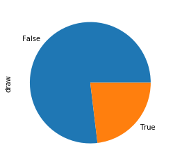

```python
df['draw'].value_counts().plot(kind='pie')
```

# Let's shift gears...

[figure not shown]

# Titanic Passenger List

- PassengerId - Unique ID of the passenger
- Survived - Survived (1) or died (0)
- Pclass - Passenger's class (1st, 2nd, or 3rd)
- Name- Passenger's name
- Sex - Passenger's sex
- Age - Passenger's age
- SibSp - Number of siblings/spouses aboard the Titanic
- Parch - Number of parents/children aboard the Titanic
- Ticket - Ticket number
- Fare - Fare paid for ticket
- Cabin - Cabin number
- Embarked - Where the passenger got on the ship (C - Cherbourg, S - Southampton, Q = Queenstown)

```python
# TDF = Titanic DataFrame
tdf = pd.read_csv('titanic_train.csv')
```

```python
tdf.head()
```

|  | PassengerId | Survived | Pclass | Name | Sex | Age | SibSp | Parch | Ticket | Fare | Cabin | Embarked |
| --- | --- | --- | --- | --- | --- | --- | --- | --- | --- | --- | --- | --- |
| 0 | 1 | 0 | 3 | Braund, Mr. Owen Harris | male | 22.0 | 1 | 0 | A/5 21171 | 7.2500 | NaN | S |
| 1 | 2 | 1 | 1 | Cumings, Mrs. John Bradley (Florence Briggs Th... | female | 38.0 | 1 | 0 | PC 17599 | 71.2833 | C85 | C |
| 2 | 3 | 1 | 3 | Heikkinen, Miss. Laina | female | 26.0 | 0 | 0 | STON/O2. 3101282 | 7.9250 | NaN | S |
| 3 | 4 | 1 | 1 | Futrelle, Mrs. Jacques Heath (Lily May Peel) | female | 35.0 | 1 | 0 | 113803 | 53.1000 | C123 | S |
| 4 | 5 | 0 | 3 | Allen, Mr. William Henry | male | 35.0 | 0 | 0 | 373450 | 8.0500 | NaN | S |

# Let's see if we can draw any conclusions?

## Like did more women or men make it off the ship?

```python
# How many men v. women on in the first place?
tdf['Sex'].value_counts()
```

```
male      577
female    314
Name: Sex, dtype: int64
```

```python
# Pandas has pivot tables, as well, by the way:
wcf = tdf.pivot_table(index='Sex', values='Survived')
# WCF = "Women and Children First!"
```

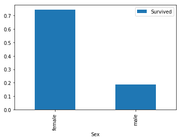

```python
# Another way to call plot(kind='bar'):
wcf.plot.bar()
```

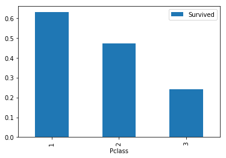

```python
# How about Passenger class?
class_warfare = tdf.pivot_table(index='Pclass', values="Survived")
class_warfare.plot.bar()
```

# Ouch.

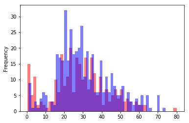

```python
# Create data frames for the survivors and the dead.
survived = tdf[tdf["Survived"] == 1]
died = tdf[tdf["Survived"] == 0]
survived["Age"].plot.hist(alpha=0.5,color='red',bins=50)
died["Age"].plot.hist(alpha=0.5,color='blue',bins=50)
```

# Let's write a method!

- Repeatable process, kinda like a macro.
- This one will take in a:
  - DataFrame
  - A list of cut points at which we want to cut the age data.
  - Labels for those cut points.
- Fill `nan` or `null` values with a standard value.
- Cut the data into age bracket categories.
- And then `return` a DataFrame with the added category.

```python
def process_age(df, cut_points, label_names):
    df["Age"] = df["Age"].fillna(-0.5)
    df["Age_categories"] = pd.cut(df["Age"],cut_points,labels=label_names)
    return df
```

```python
cut_points = [-1,0,5,12,18,35,60,100]
label_names = ["Missing","Infant","Child","Teenager","Young Adult","Adult","Senior"]
tdf = process_age(tdf, cut_points, label_names)
```

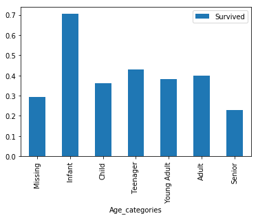

```python
tpv = tdf.pivot_table(index='Age_categories', values='Survived')
tpv.plot.bar()
```

# Notable Packages for Data Science

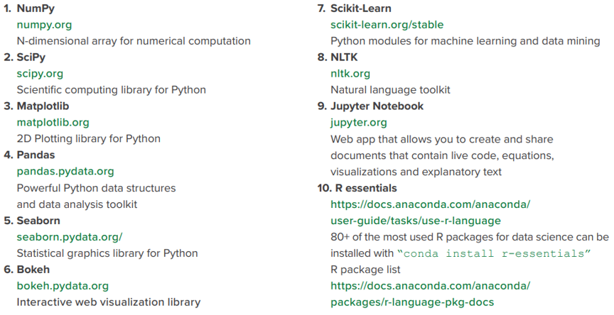

# Recommended Installation: Anaconda Distribution

- Available at [Anaconda.com](https://www.anaconda.com/downloads)
- 1,500+ Pre-Installed, Pre-Configured Packages for Science, Data Science, and Tons of Other Things
- Easy Package Updating
- Easy-to-Use Environment Manager (a topic for a later date)
- [Good Getting Started Guide](https://conda.io/projects/conda/en/latest/user-guide/getting-started.html)

# Other Introductory Options

- [Microsoft Azure Notebooks](https://notebooks.azure.com/)
- [Kaggle](https://www.kaggle.com/learn/python)
- [LearnPython.com](https://www.learnpython.org/)
- [Coder.com](https://coder.com/)

# Additional Resources

- [Microsoft's 44-part Python for Beginners YouTube series](https://www.youtube.com/playlist?list=PLlrxD0HtieHhS8VzuMCfQD4uJ9yne1mE6)
- [RealPython.com](https://www.realpython.com)
- [Practical Business Python](https://pbpython.com)
- [Talk Python To Me Podcast](https://talkpython.fm)
- [PythonBytes Podcast](https://pythonbytes.fm)

# Thank you!

[figure not shown]